# ReportPart2

Coskun & Kaan & Talha

28 10 2019

## Project Part 2

For part 2 of the project car scratch image has chosen to be inspected in following assignments.

### Project Part 2.1

Jpeg library is included to project for the purpose of reading image file and turning it into an array.Image is read as an array.Histogram of image is plotted.

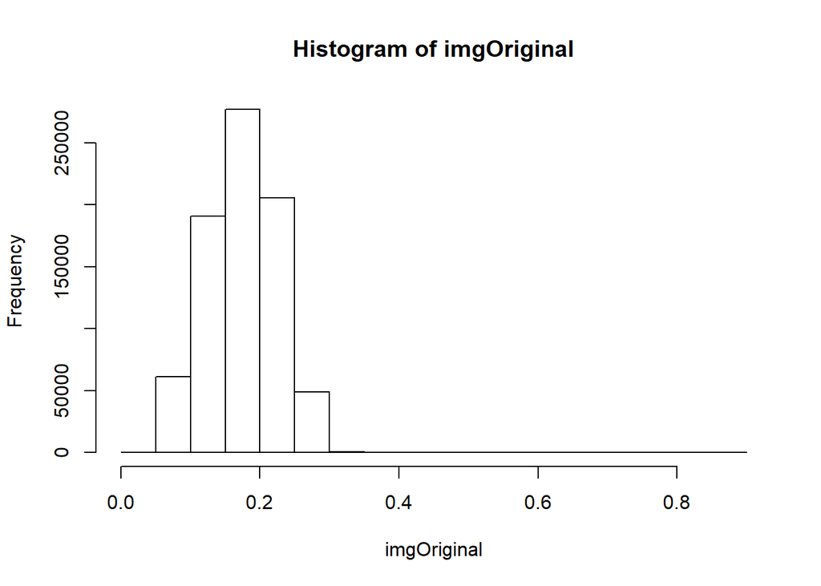

Mean, median, standard deviation and variance values are listed in order to investigate and interpret the distrubition of the values in array.

```r
mean(imgOriginal)
```

```
## [1] 0.1771889
```

```r
median(imgOriginal)
```

```
## [1] 0.1803922
```

```r
sd(imgOriginal)
```

```
## [1] 0.05577123
```

```r
var(imgOriginal)
```

```
## [1] 0.00311043
```

Since the histogram of the values seem in a bell shape, the distribution can fit this image values. On the other hand, median and mean values are close and thereby skewness is very low, which is a property of the normal distribution.

### Project Part 2.2

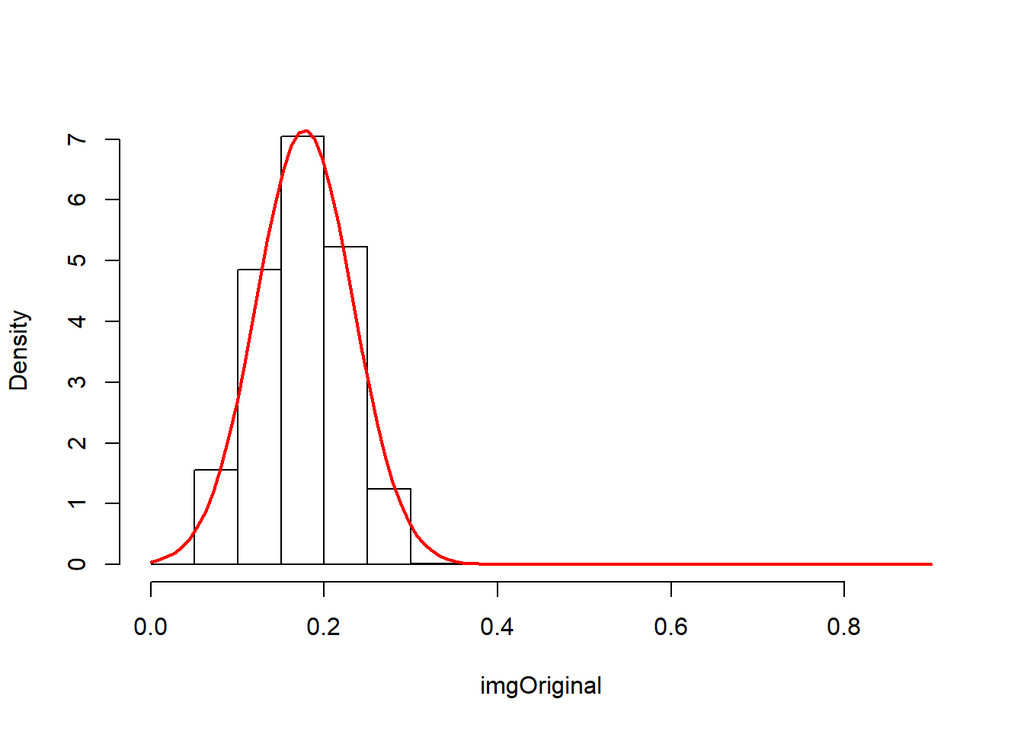

```r
library(MASS)
set.seed(101)
fit <- fitdistr(imgOriginal, densfun="normal")
hist(imgOriginal, pch=20, breaks=25, prob=TRUE, main="")
curve(dnorm(x, fit$estimate[1], fit$estimate[2]), col="red", lwd=2, add=T)
```

```r
fit
```

```
##        mean            sd
##   1.771889e-01   5.577119e-02
##  (6.288967e-05) (4.446971e-05)
```

Previously, it is assumed that the pixel values are distributed normally; therefore a normal distribution that fits well is found. The normal curve is shown on the histogram and mean, standard deviation. and variance values are returned. The parameters of normal distribution are mean and variance so we can conculde that the pixel values are distributed normally with mean = 0.1771889 and variance = 0.00311043.

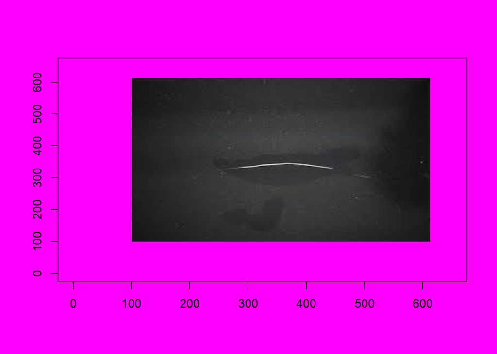

```r
require(grDevices)
op <- par(bg = "magenta")
plot(c(0, 650), c(0, 650), type = "n", xlab = "", ylab = "")
rasterImage(imgOriginal, 100, 100, 612, 612, interpolate = FALSE)
```

```r
par(op)
```

For understading behaviour of our image, we have plotted it to see virtually with the help of rasterImage function.

### Project Part 2.3

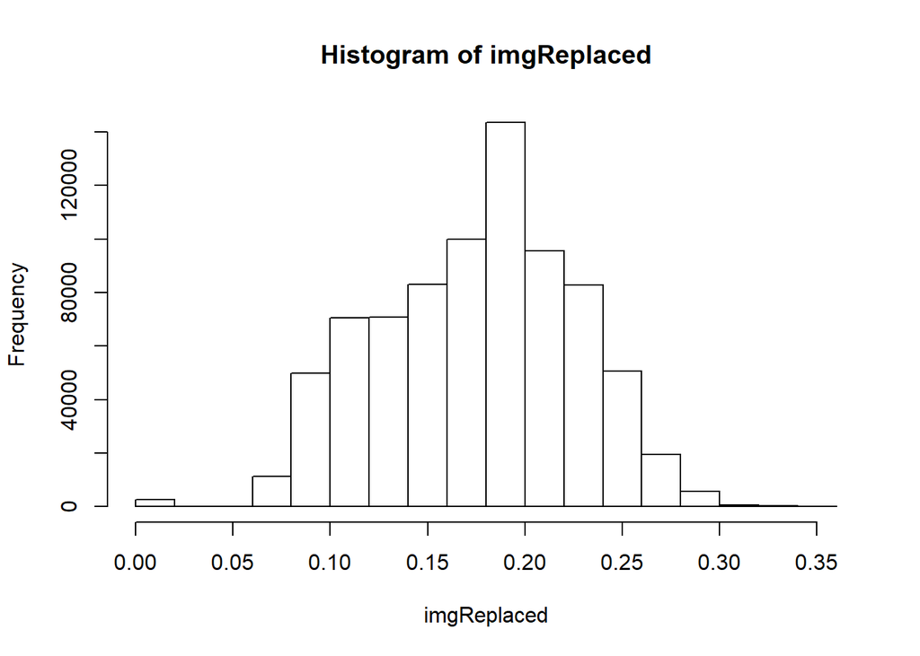

```r
lowerbound <- qnorm(0.001)*sd(imgOriginal)+mean(imgOriginal)
upperbound <- qnorm(0.999)*sd(imgOriginal)+mean(imgOriginal)
imgTemp <- imgOriginal
imgTemp[imgTemp < lowerbound | imgTemp > upperbound] = 0
imgReplaced <- imgTemp
hist(imgReplaced)
```

```r
mean(imgReplaced)
```

```
## [1] 0.175314
```

```r
median(imgReplaced)
```

```
## [1] 0.1803922
```

```r
sd(imgReplaced)
```

```
## [1] 0.05096239
```

```r
var(imgReplaced)
```

```
## [1] 0.002597165
```

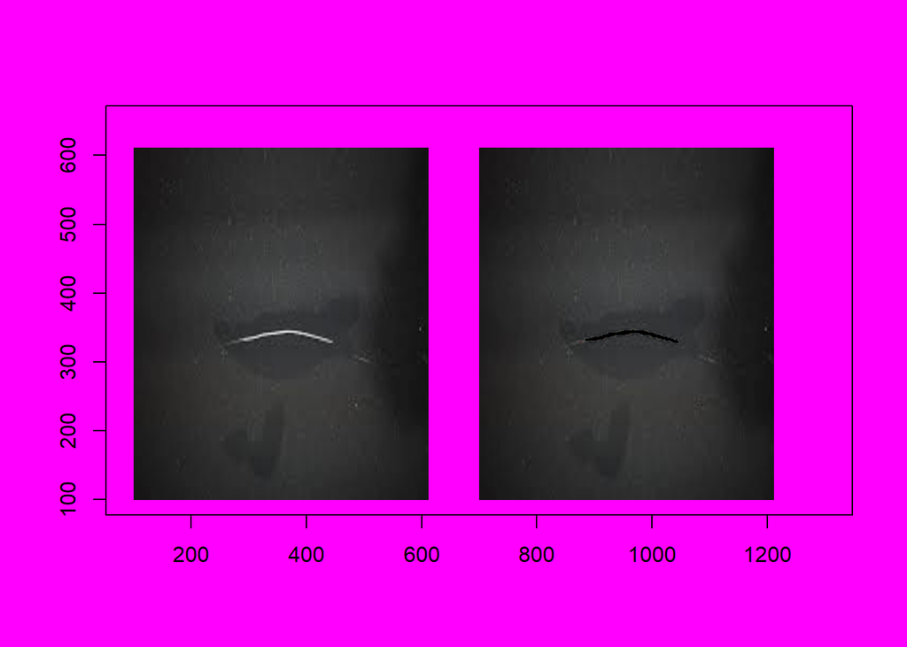

```r
require(grDevices)
op <- par(bg = "magenta")
plot(c(100, 1300), c(100, 650), type = "n", xlab = "", ylab = "")
rasterImage(imgOriginal, 100, 100, 612, 612, interpolate = FALSE)
rasterImage(imgReplaced, 700, 100, 1212, 612)
```

```r
par(op)
```

Initial image (imgOriginal) and the image (imgReplaced) that pixel values replaced with 0 has been rastered together to compare both states. As it can be seen in the plot, out of control values are turns out 0 which indicates itself with black color in the plot. White pixels in the other words pixel values close to 1 can be called out of control values in our image. In a nutshell, scratch on the car converted to black in the updated image.

### Project Part 2.4

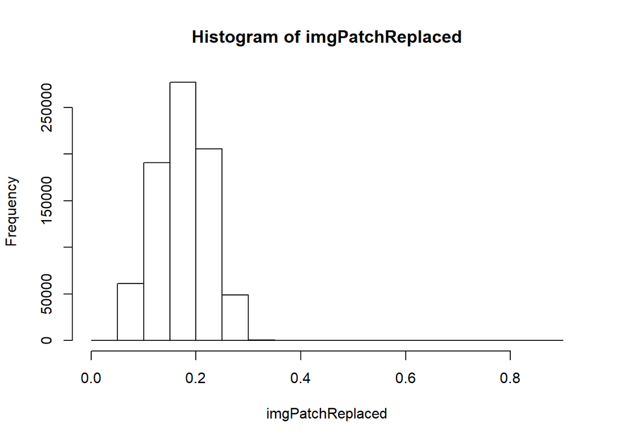

```r
imgPatchReplaced <- imgOriginal
hist(imgPatchReplaced)
```

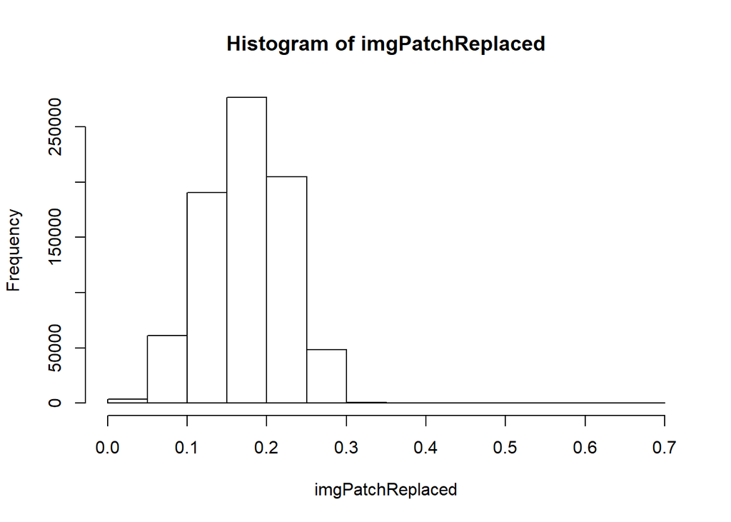

```r
for (i in 1:10) {
  for(j in 1:10){
    tempimgReplaced <- imgPatchReplaced[(1+(51*(i-1))):(51*i),(1+(51*(j-1))):(51*j),1:3]
    lowerbound <- qnorm(0.001)*sd(tempimgReplaced)+mean(tempimgReplaced)
    upperbound <- qnorm(0.999)*sd(tempimgReplaced)+mean(tempimgReplaced)
    tempimgReplaced[tempimgReplaced < lowerbound | tempimgReplaced > upperbound] = 0
    imgPatchReplaced[(1+(51*(i-1))):(51*i),(1+(51*(j-1))):(51*j),1:3] <- tempimgReplaced[1:51,1:51,1:3]
  }
}
hist(imgPatchReplaced)
```

Rather than splitting the images and importing them manually, We have iterated over the array of our original image. In each iteration we have selected specific area then found upper and lower bound of this area, and replaced with 0 for the pixels that are out of our bounds for this specific area then updated the area of the original array that we selected before.

```r
sd(imgPatchReplaced)
```

```
## [1] 0.05282292
```

```r
var(imgPatchReplaced)
```

```
## [1] 0.00279026
```

```r
mean(imgPatchReplaced)
```

```
## [1] 0.1755292
```

```r
median(imgPatchReplaced)
```

```
## [1] 0.1803922
```

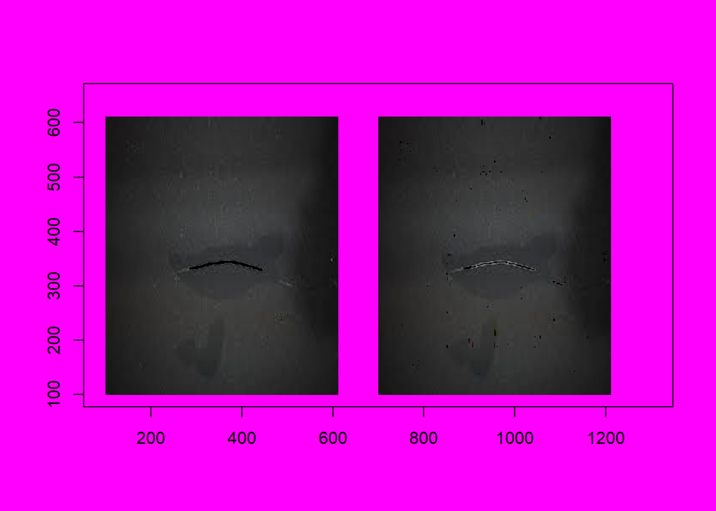

```r
require(grDevices)
op <- par(bg = "magenta")
plot(c(100, 1300), c(100, 650), type = "n", xlab = "", ylab = "")
rasterImage(imgReplaced, 100, 100, 612, 612, interpolate = FALSE)
rasterImage(imgPatchReplaced, 700, 100, 1212, 612)
```

```r
par(op)
```

To compare the result of part 3 and part 4 we have rastered images together.It is so obvious that part 3 is better for detecting outliers. In part 4, sample size is very small compared to part 3, therefore, part 4 fails to detect outliers. In our image, out of control values are clusted in the middle and this is why we end up with such kind discrepancy between part 3 and part 4. In a case that out of control parameters are distributed uniformly all over the image, this two methods can go hand in hand.